### Description

- Very similar to deterministic regression imputation but as an extra step adds noise (random draw from residual) to predictions to account for the uncertainty in imputation.

#### Example

```r
# remove rows with no information, add indicator variable for whether a row requires imputation or not.
data <- airquality[, c("Ozone", "Solar.R")]  %>%
  filter(!is.na(Ozone) | !is.na(Solar.R)) %>%
  mutate(imputed_or_not = if_else(is.na(Ozone) | is.na(Solar.R) , "imputed", "observed"))

# "method = norm.nob" applies imputation to "data" (w/o indicator) using stochastic regression. The other parameters in mice() aren't relevant for this section.
imp <- mice(data %>% select(Ozone, Solar.R), method = "norm.nob", m = 1, maxit = 1, seed = 1, print = FALSE)
imputed_airquality_dataset <- complete(imp) %>% add_column(data$imputed_or_not) %>% rename(imputation_indicator = "data$imputed_or_not")
```

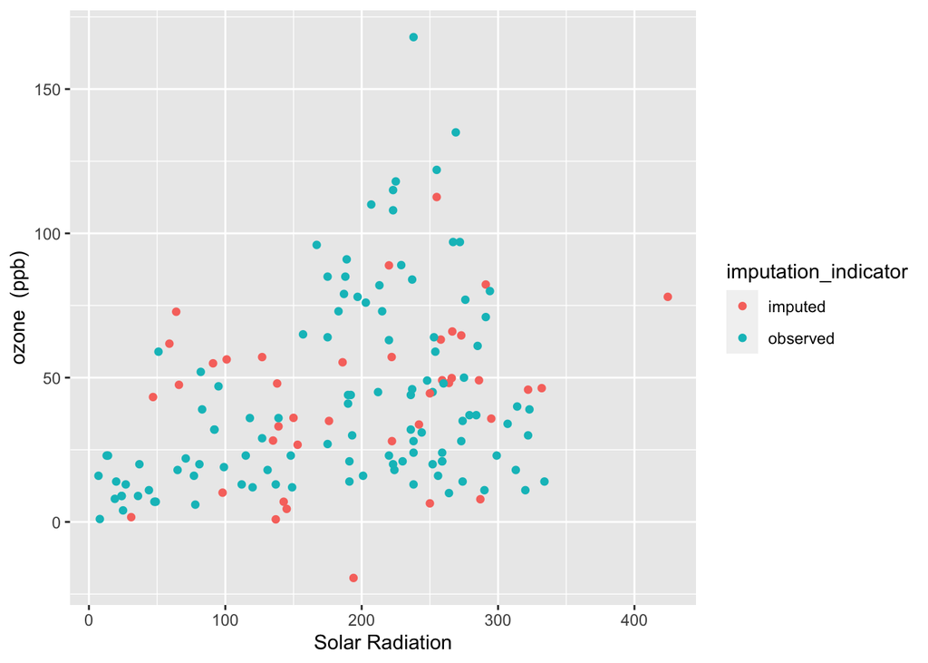

```r
imputed_airquality_dataset %>%
  ggplot(aes(x = Solar.R,y= Ozone, color = imputation_indicator)) +
  geom_point() +
  labs(y = "ozone  (ppb)",
       x = "Solar Radiation")
```

#### Recall the deterministic regression imputation plot and note the random noise added to imputed values above:

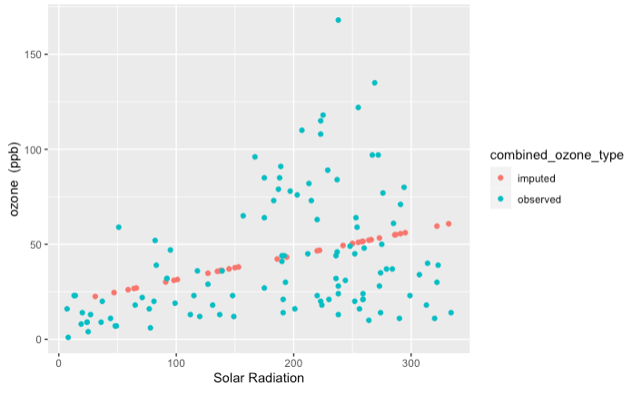

### Pros

- Unlike deterministic regression imputation, preserves correlation between variables.
- Initially counterintuitive to add random noise to our perfectly adequate prediction model, but this is in fact ideal for having the imputed values mimic the uncertainity in the unknown values.

### Cons

- Can lead to extreme values such as negative values [e.g. negative ozone shown in example above], which are impossible in real-world.
- This model assumes equal dispersion of data for the entire linear model. Hence, not accurate for heteroscedastic (non-costant variance) distributions. In the example above, observed dispersion is more extreme in the 200~300Ly Solar.R band, but imputed values do not acocunt for this and follow same degree of dispersion throughout.